# 1st grade obesity and overweight in Alachua County

Ben Brew and Joe Brew

September 11, 2015

This report briefly summarizes and visualizes the distribution of “obese” 1st graders across schools, socioeconomic status, and race in Alachua County public schools. The obesity rate is defined as the proportion of students classified as obese or overweight. according to his or her body mass index (BMI). The time period of interest is 2007-2014.

# Obesity Trends of the Entire 1st Graade Population from 2007-2014

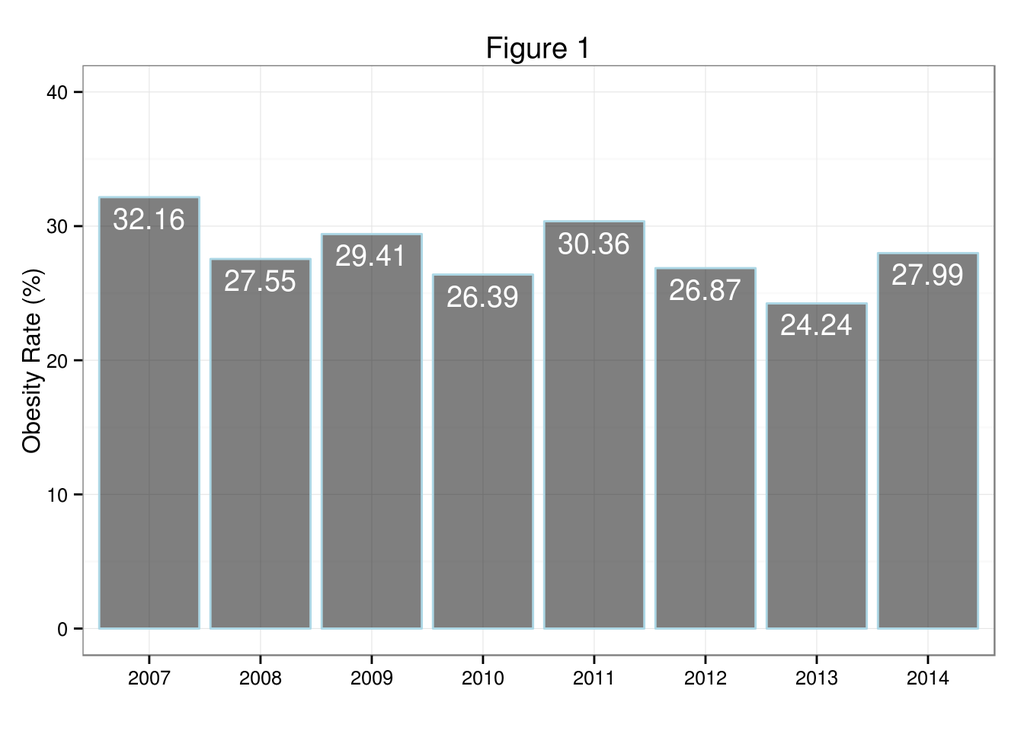

Figure 1 shows the obesity rate for all 1st graders by year. First grade obesity varies between 24% and 32% since 2007, with it peaking in 2007 and bottoming out in 2013. Figure 2 shows the obesity rate by race over time (2007-2014). Asian 1st graders enjoy the lowest obesity rate followed by their White classmates. Black and Hispanic 1st graders have a consistently and substantially higher obesity rate converging to a rate nearly twice as high as their Asian classmates in 2014.

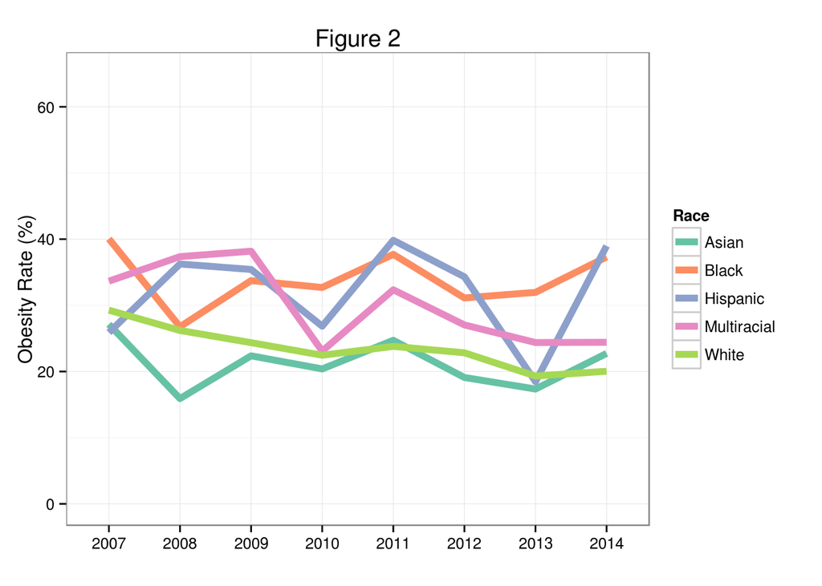

Figure 3, below, plots the obesity rate by lunch status. Lunch status is the closest proxy for income available in the data. Those qualifying for free lunch do so as a result of a lower family income. Besides 2008, students who receive free lunch have a significantly higher obesity rate.

Figure 4 shows the same discrepancy does not exist between male and female students. Over time, the obesity rate for both sexes has remained largely similar. However, in 2014, the obesity rate for female 1st graders a is roughly 5% higher than male 1st graders

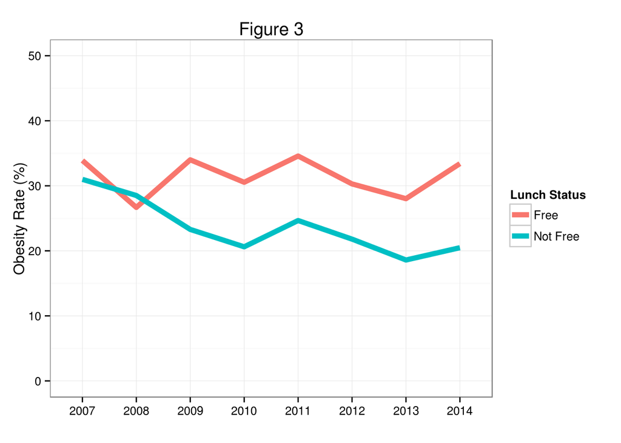

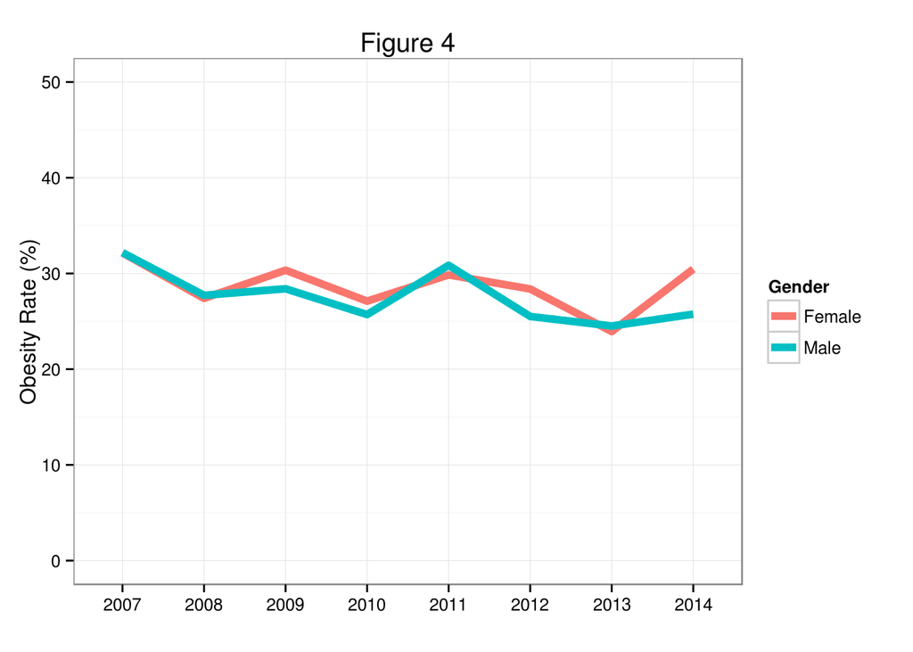

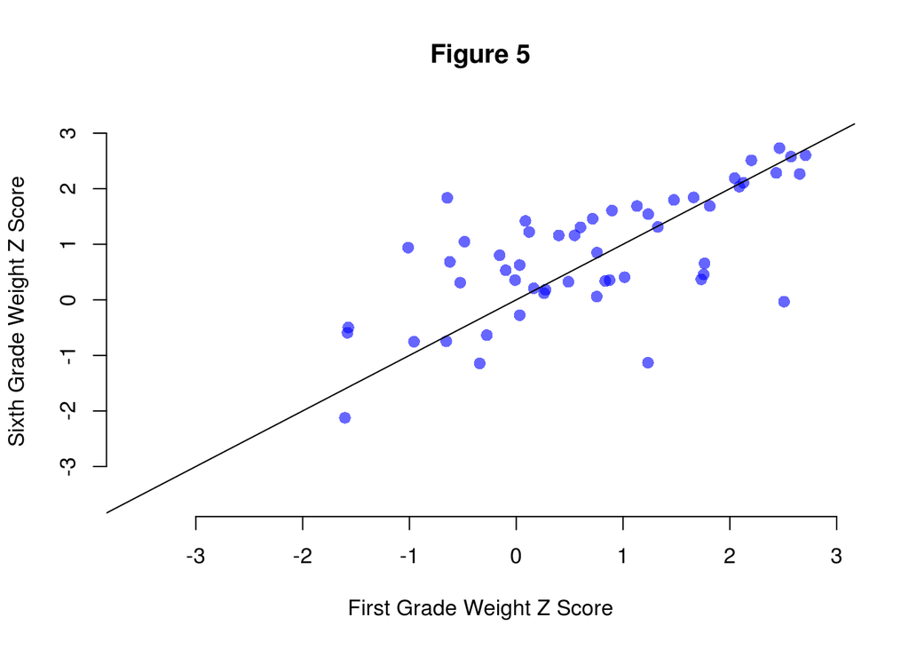

Student weight data is collected in 1st, 3rd, and 6th grade. Firgure 5 shows the correlation between a students weight (BMI z score) in 1st and 6th grade. If a student’s weight in 1st grade was exactly correlated with his or her 6th grade weight, the observations should fall close to the 45 degree line. The sample size was heavily restricted due to lack of data for students with both 1st and 6th grade weight scores, however the uniformity of the data points around the 45 degree line suggests that weight in 1st grade is predictive of weight in 6th grade.

# Obesity Rates by School

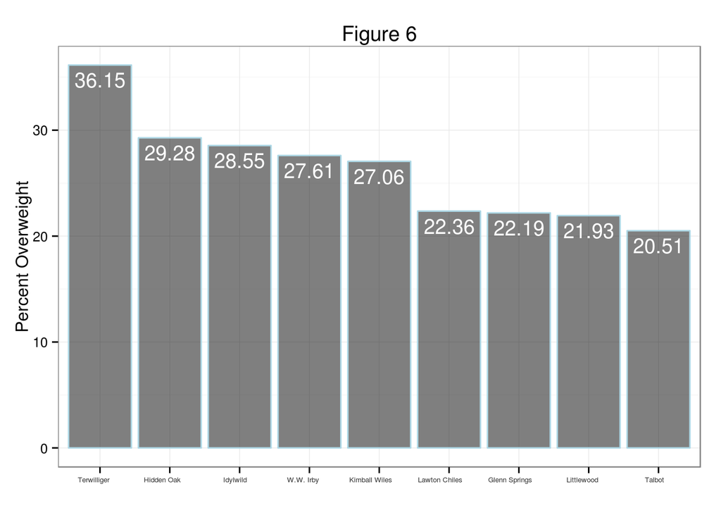

Figure 6 gives the average obesity rate for schools in Alachua county that have a 1st grade population over 600 students from 2007-2014. Smaller schools are kept out of the remaining analysis due to the high variability of their obesity rates. Tewiliger has the highest average obesity rate for 1st graders among the larger schools at 36.15%.

Figure 7 shows how the obesity rater for the same large schools changes over time. Although Hidden Oak had the highest 1st grade obesity rate in 2007, it rapidly decreased over time. Terwiliger, on the other hand, exerienced a consistently high 1st grade obesity rate with a spikes in 2007 and 2014. Both Talbot and Littlewood Elementary school have consistently low obesity rates throughout the observed time period.

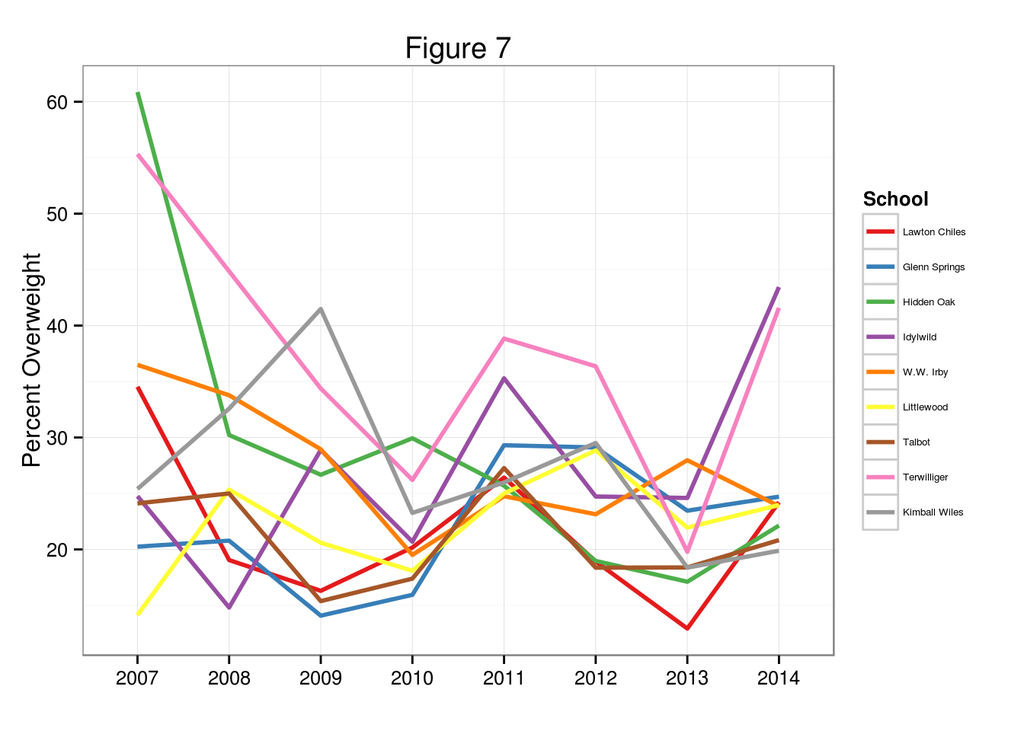

## Obesity Rates Within Schools

In this section we take a more in depth look at obesity rates among 1st graders in larger schools. That is, schools with a 1st grade population over 600.

#### Lawton Chiles Elementary School

Lawton Chiles Elementary School had a total of 832 1st grade students between 2007 and 2014 and an average obesity rate of 22.36% for all first graders. Figure 8 shows the proportions of those students who are classified as overweight according to their BMI.

In line with the general trend, Asian 1st graders at Lawton Chiles have a significantly lower obesity rate relative to their 1st grade class mates.

Figure 10 shows that in recent years, female 1st graders at Lawton Chiles have a higher obesity rate than their male classmates. The other years show a much higher obesity rate for males than females. The general trend for both males and females is neigher substantially rising or falling over time.

figure 11 show the relationship between obesity and free lunch status. Those qualifying for free lunch have, on average, a higher obesity rate, but it varies depeding on the year. Obesity rates for both populations looked to be decreasing in recent years, but 2014 shows a slight increase in students not qualifying for free lunch and a large increase for those 1st graders qualifying for free lunch.

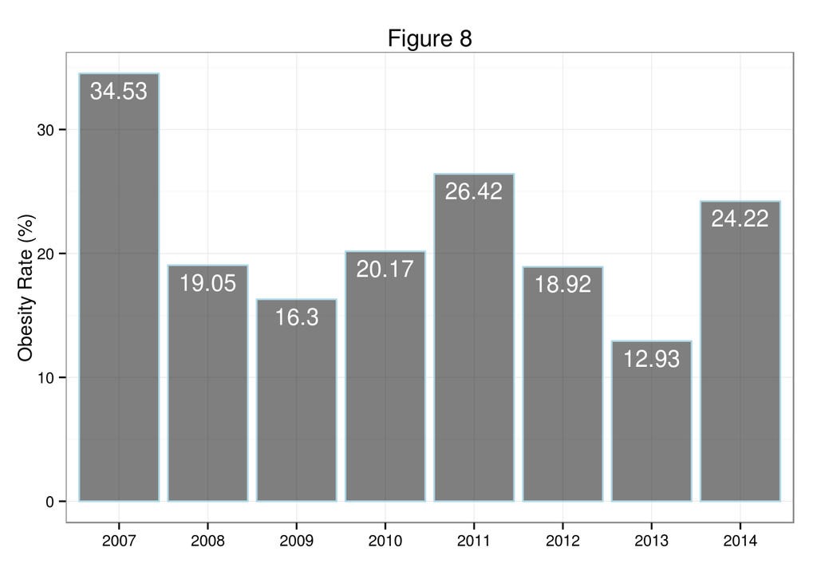

### Obesity rate by race aggregated 2007-2014

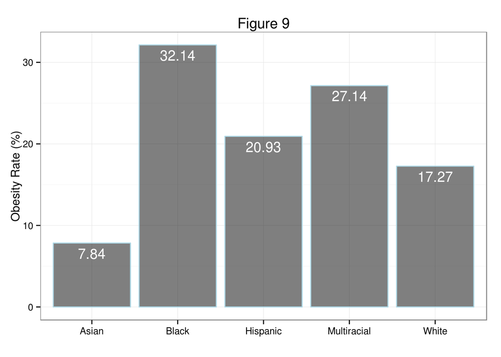

### Obesity rate by gender (2007-2014)

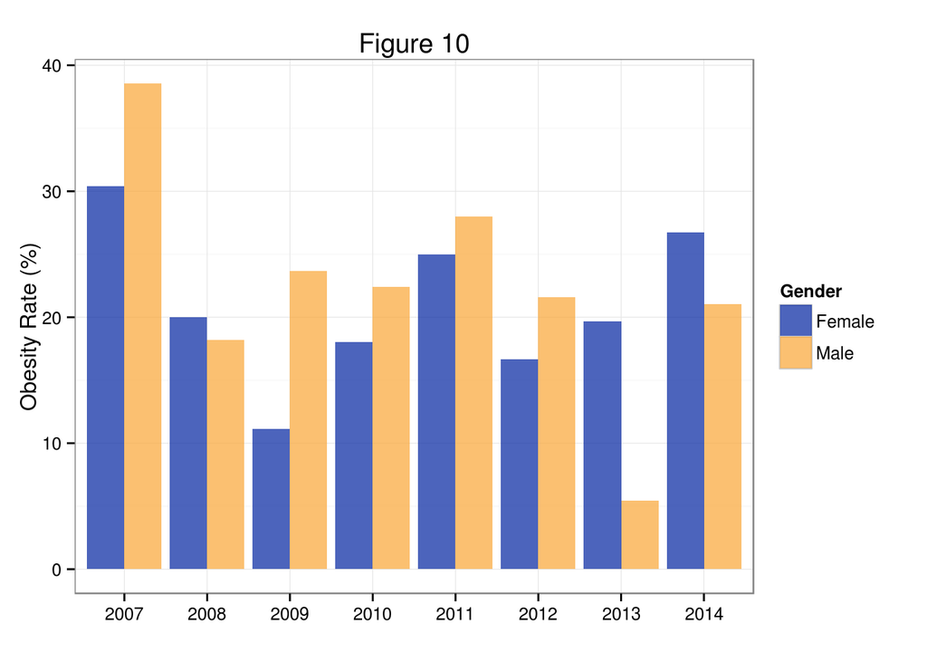

### Obesity rate by lunch (2007-2014)

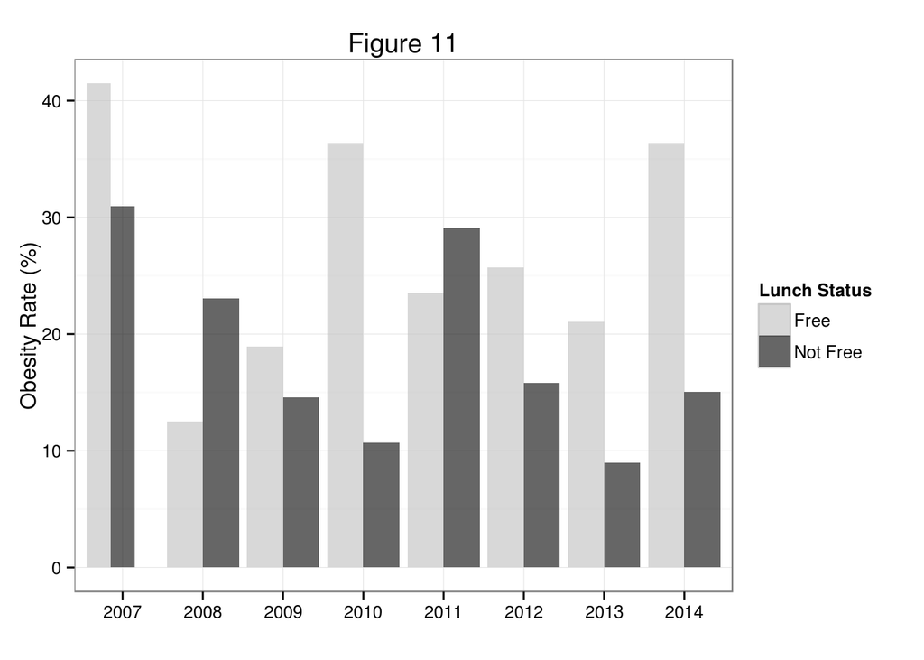

## Glenn Springs Elementary

Glenn Springs Elementary had a total of 604 1st graders between 2007 and 2014 and an average obesity rate of 22.19%. Figure 12 shows a peak in obesity rates in 2011 and 2012. Unlike Lawton Chiles, multiracial students make up the highest proportion of overweight 1st graders, followed by asians (Figure 13). This due mainly to a smaller sample size for the Asian population.

There is no significant difference between obesity rate among male and female students. The same holds for students who qualified for free lunch and those who did not (figure 14 & 15)

### Obesity Rate by Year

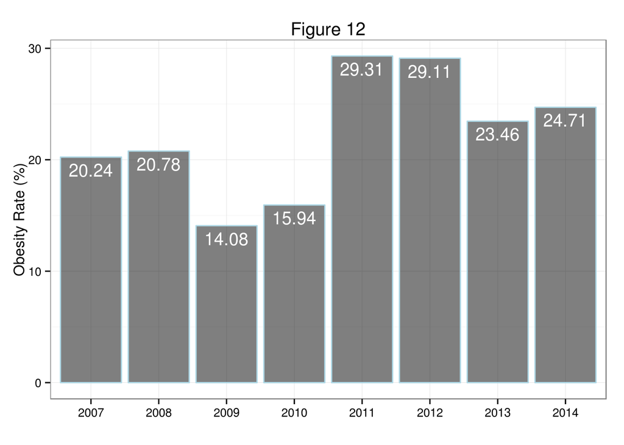

### Obesity rate by race aggregated 2007-2014

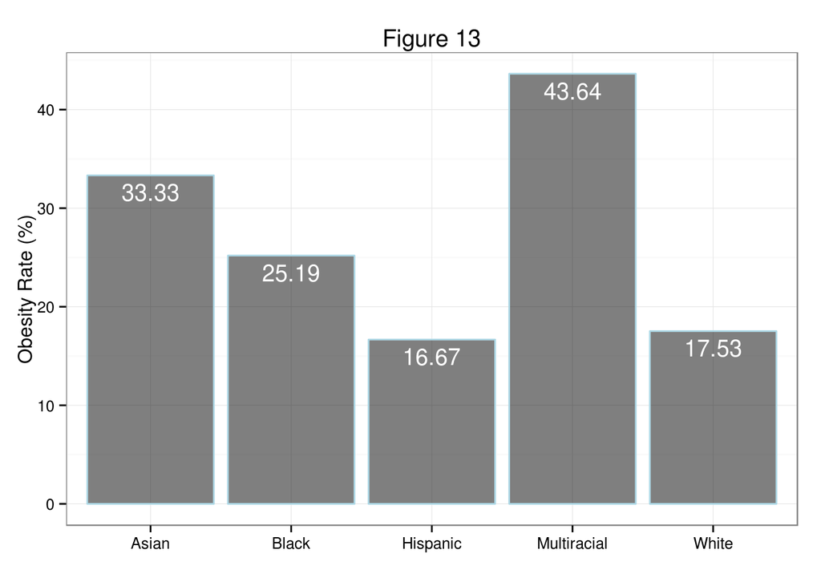

### Obesity rate by gender (2007-2014)

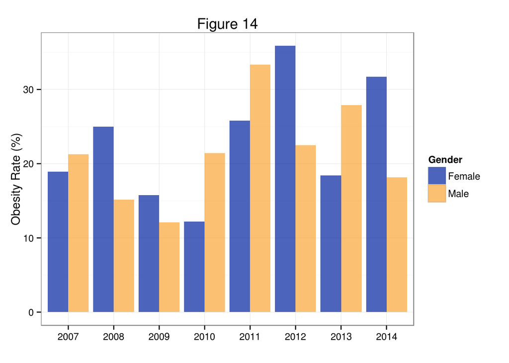

### Obesity rate by lunch status (2007-2014)

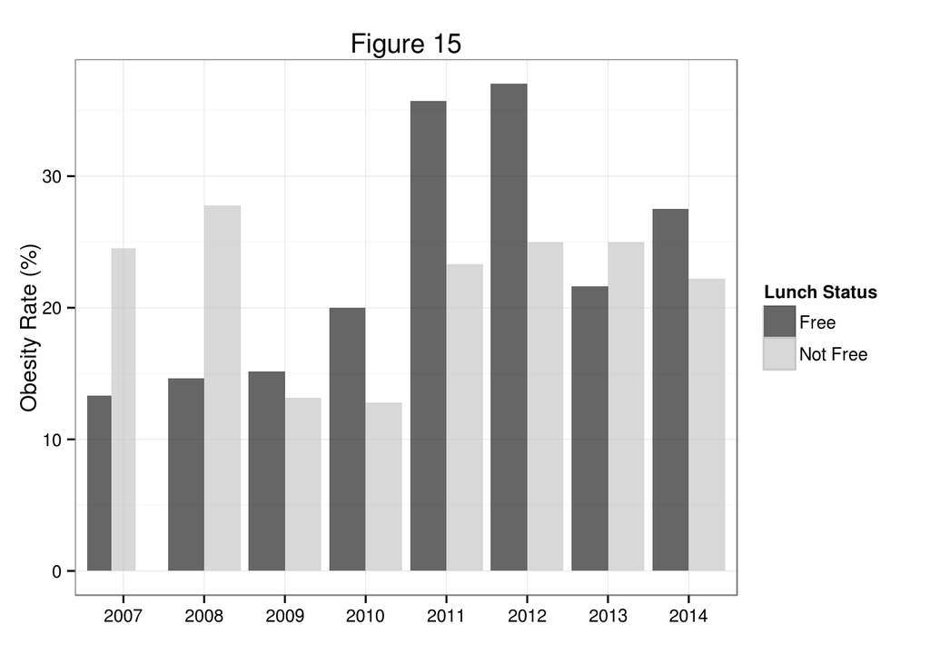

## Hidden Oak Elementary

In 2007 the high obesity rate was driven by the male 1st graders and those who did not qualify for free lunch. Both of these populations have seen a steadily falling obesity rate since 2007, whereas students qualifying for free lunch have followed a much more unstable trend (figure 18 & 19)

### Obesity Rate by Year

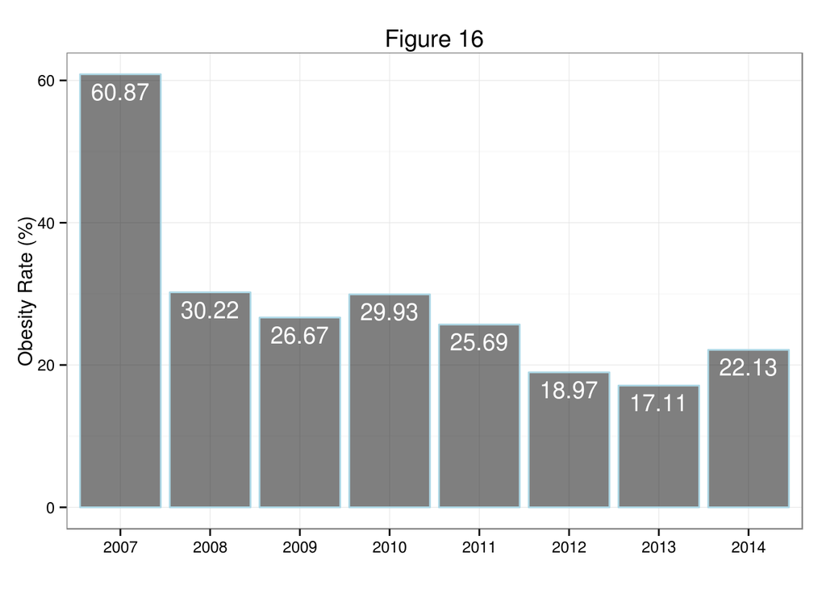

### Obesity rate by race aggregated 2007-2014

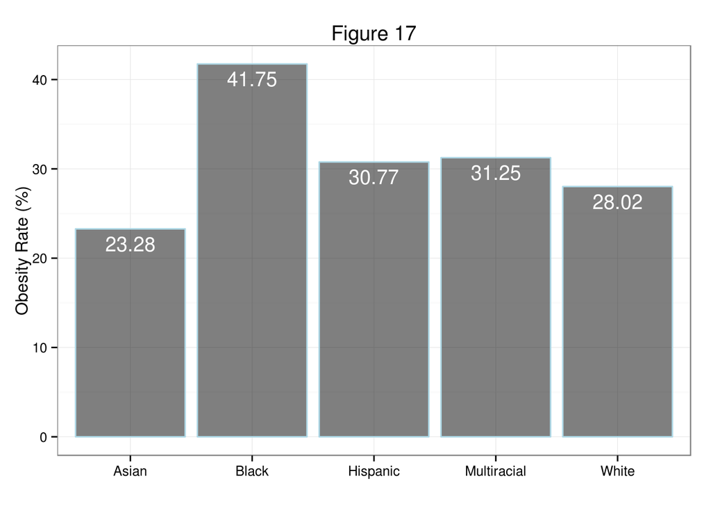

### Obesity rate by gender (2007-2014)

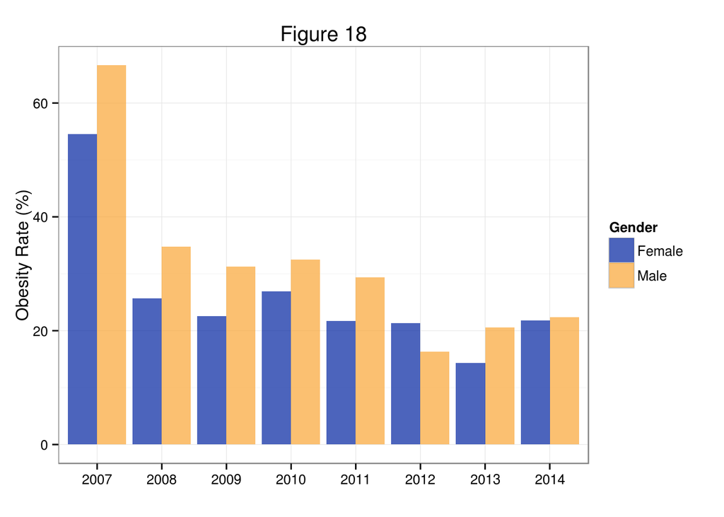

### Obesity rate by lunch status (2007-2014)

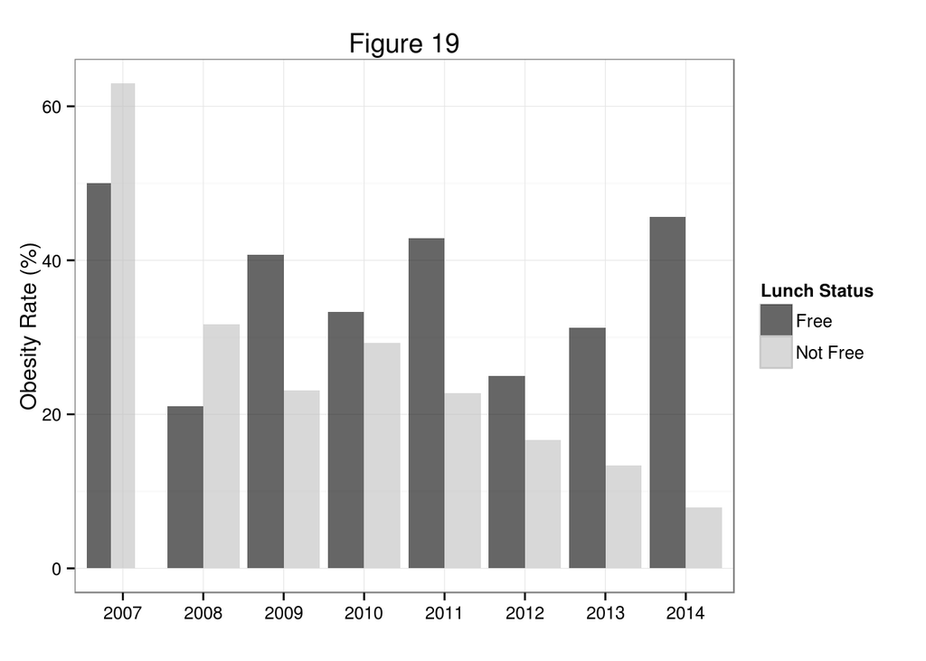

## Idylwild Elementary

Idylwild Elementary had 781 total 1st graders between 2007-2014 and 28.55 average obesity rate, 3rd among all large Alachua County public schools. Unlike Hidden Oak, Idylwild’s higher ranking is a result of a high obesity rate in 2014 (43.44%).

The hispanic 1st grade population has the highest obesity rate at Idylwild at 46.27%. The relationship between obesity and gender shows no striking temporal patterns. This is also true for free lunch status.

### Obesity Rate by Year

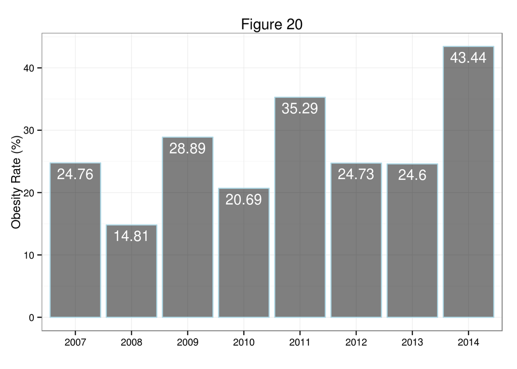

### Obesity rate by race aggregated 2007-2014

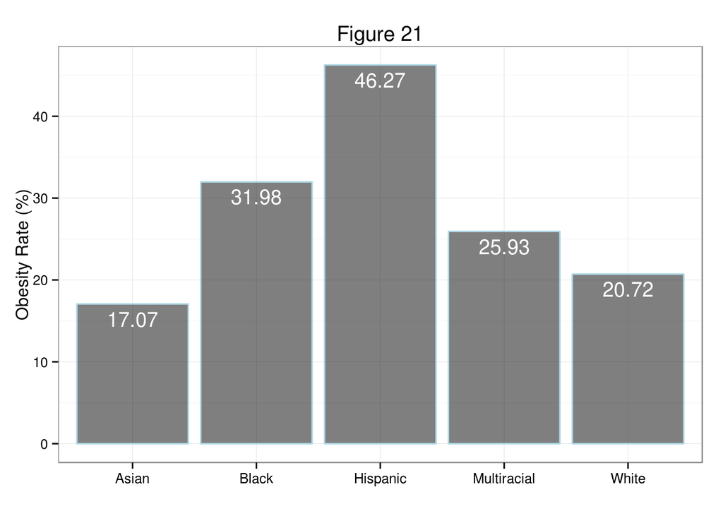

### Obesity rate by gender (2007-2014)

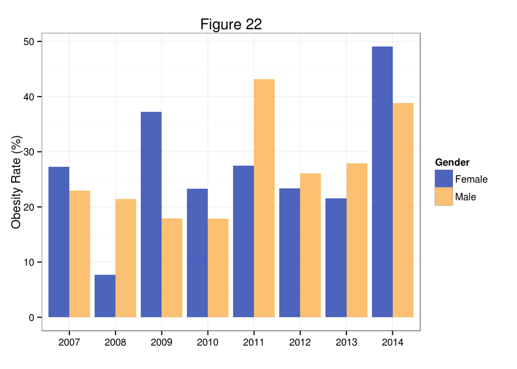

### Obesity rate by lunch status (2007-2014)

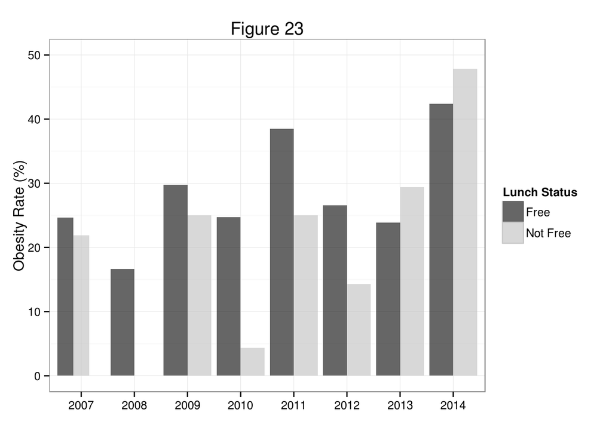

## W.W. Irby Elementary

W.W. Irby Elementary had 996 total 1st graders in the 2007-2014 time period and an average 27.62 obesity rate (4th among large schools). W.W. Irby Elementary School’s 1st grade obesity rate was at it’s highest in 2007 (36.49%) and steadily decreased until it reached it’s low in 2010 (19.51%). It has slightly increased again in recent years at 23.87% in 2014 (figure 24)

Hispanic 1st graders at W.W. Irby have the highest obesity rate at 37.78 (figure 25). From 2007-2010, 1st graders who did not qualify for free lunch had a substantially higher obesity rate relative to their lower income classmates. The opposite is true for the years 2011-2014.

### Obesity Rate by Year

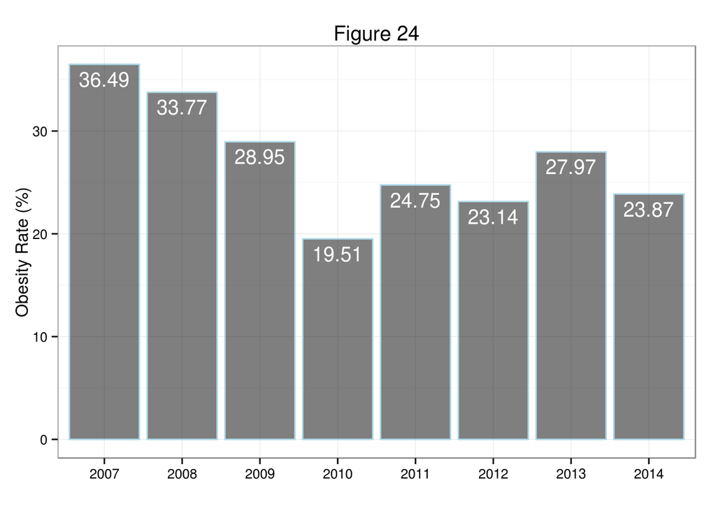

### Obesity rate by race aggregated 2007-2014

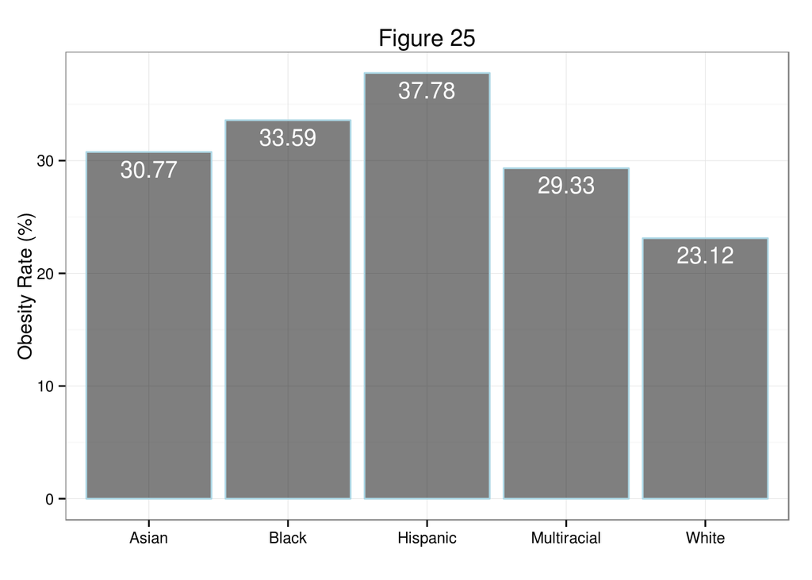

### Obesity rate by gender (2007-2014)

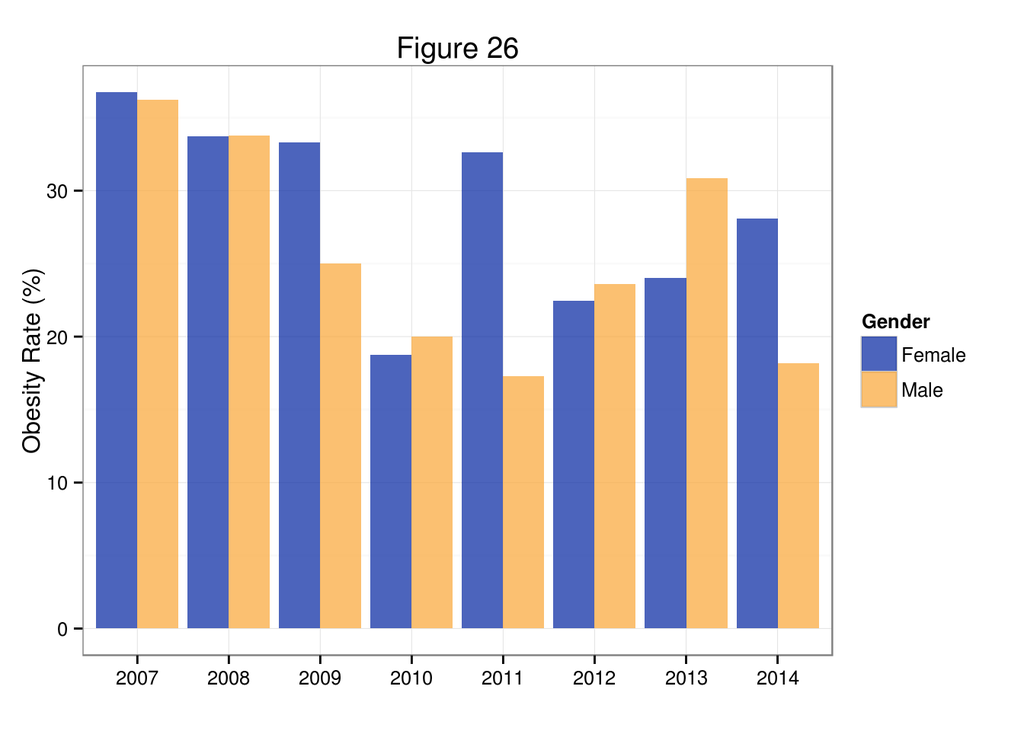

### Obesity rate by lunch status (2007-2014)

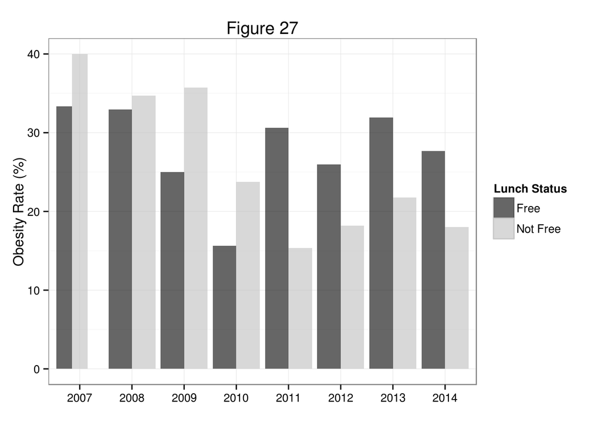

## Littlewood Elementary

Littlewood Elementary had 675 total 1st graders in the time period 2007-2014 and an average obesity rate of 21.93 (second to lowest in large schools).

In 2007, Littlewood had very low obesity rate at 14.13% among 1st graders (figure 28). This number has increase in recent years with a peak in 2012 (28.85%). In line with most schools, the Asian 1st graders at Littlewood have the lowest obesity rate (13.33%) over the time period 2007-2014, whereas Black students have the highest (figure 29).

### Obesity Rate by Year

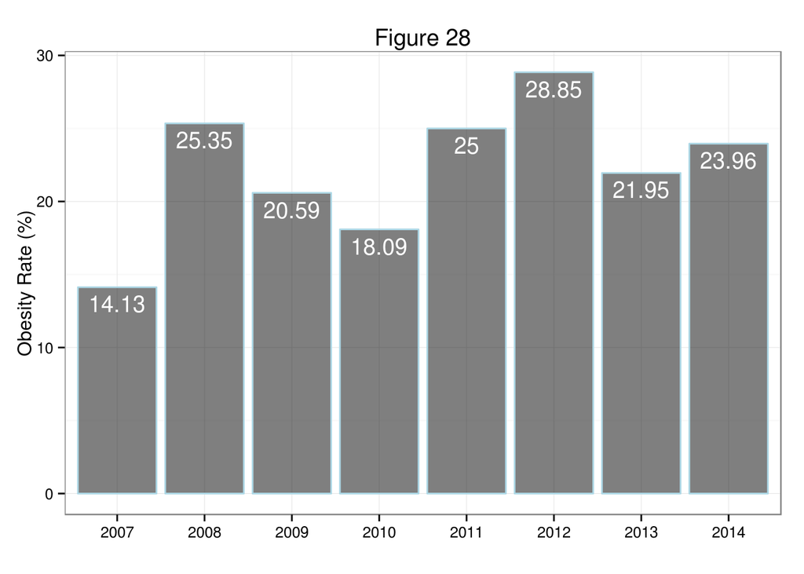

### Obesity rate by race aggregated 2007-2014

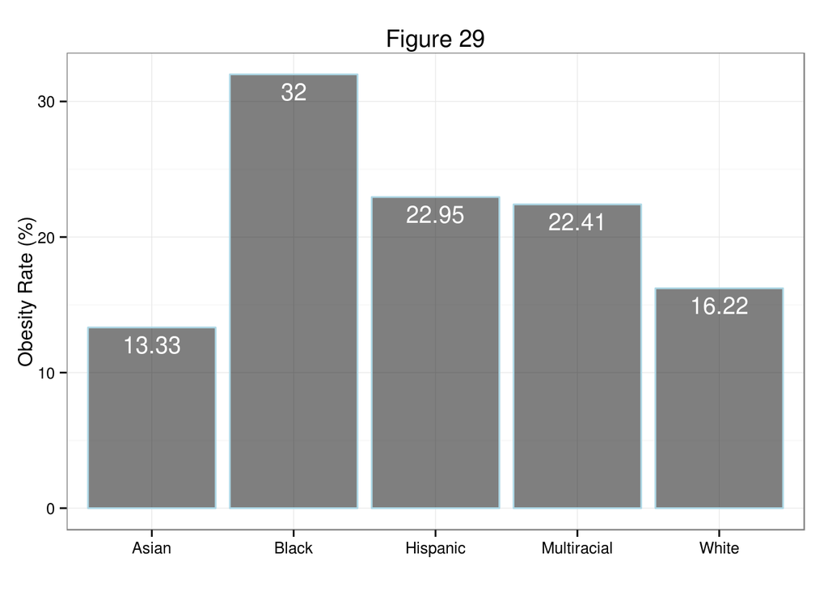

### Obesity rate by gender (2007-2014)

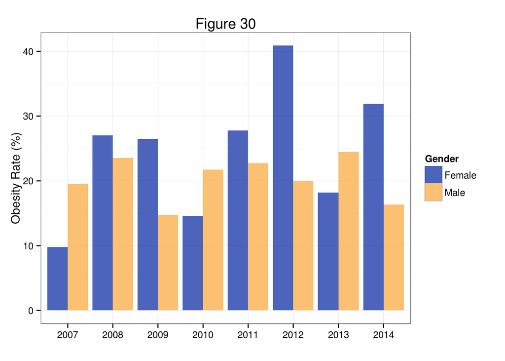

### Obesity rate by lunch status (2007-2014)

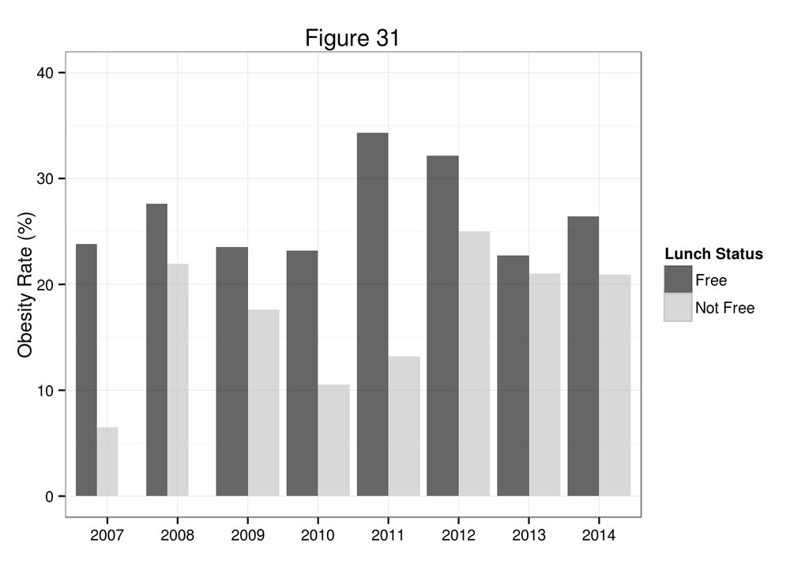